# JK Flip-flop not Behavioral (VHDL version)

Hardware

Easy to write a behavioral description of JK-FF in VHDL, what about writing it in terms of *gates*?

Author

Marcobisky

Published

December 8, 2024

## Intro

Most online VHDL descriptions of JK flip-flops (FF) are based on “processes” or circuit functionality (behavioral). Is it possible to simulate them only by constructing the circuit structure of the JK flip-flop?

## JK FF Review

The circuit structure is JK FF is very familiar to everybody, which is:

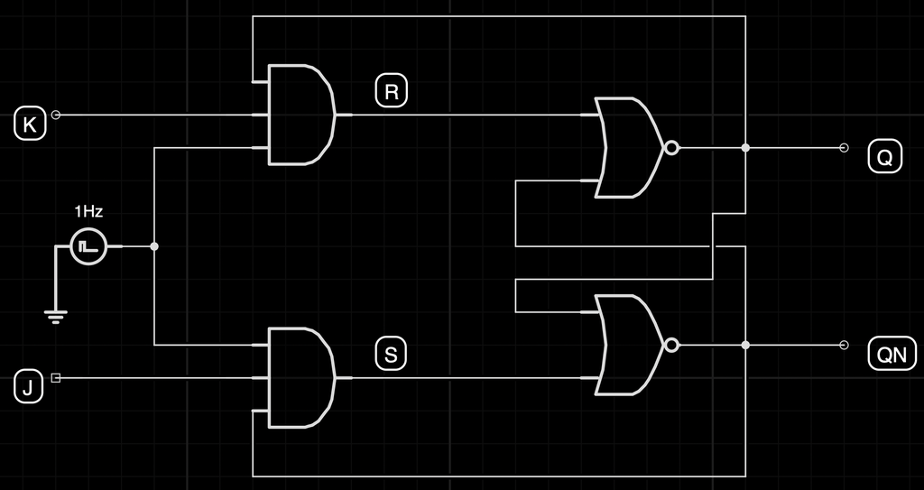

The corresponding truth table is shown below:

| C | J | K | Q | Q̅ |
| --- | --- | --- | --- | --- |
| ↑ | 0 | 0 | latch | latch |
| ↑ | 0 | 1 | 0 | 1 |
| ↑ | 1 | 0 | 1 | 0 |
| ↑ | 1 | 1 | toggle | toggle |
| x | 0 | 0 | latch | latch |
| x | 0 | 1 | latch | latch |
| x | 1 | 0 | latch | latch |
| x | 1 | 1 | latch | latch |

where “latch” represent the `Q` output remembers whatever the last stored value was. “Toggle” means to flip `Q`, i.e. 0 -> 1, 1 -> 0. “↑” means the clock signal in a leading edge.

## Problem

### First try

```
library IEEE;
use IEEE.STD_LOGIC_1164.ALL;

entity JKFF_nodelay is
    Port (
        J : in STD_LOGIC;     -- J input
        K : in STD_LOGIC;     -- K input
        clk : in STD_LOGIC;   -- Clock input
        Q : out STD_LOGIC;    -- Output Q
        QN : out STD_LOGIC    -- Output QN (complement of Q)
    );
end JKFF_nodelay;

architecture Structural of JKFF_nodelay is
    -- Internal signals for latch and clock gating
    signal S, R : STD_LOGIC;    -- Set and Reset inputs for the latch
    signal Q_int, QN_int : STD_LOGIC := '0'; -- Internal Q and QN for feedback

begin
    S <= (J and clk) and QN_int;
    R <= (K and clk) and Q_int;

    -- NOR gate-based latch
    Q_int <= not (R or QN_int);
    QN_int <= not (S or Q_int);

    -- Outputs
    Q <= Q_int;    -- Main output
    QN <= QN_int;  -- Complementary output
end Structural;
```

Then write a testbench file to test the behavior of this circuit, you will find it will not work well.

### Reason

The reason (probably, only personal view) is that JK FF have two layers of feedback (instead of SR FF, which just have one), since we loop our output `Q` not only to the NOR gates, but also AND to our initial inputs J and K. This confuse the compiler because the resultant signal changes so fast and maybe not have a stable consequence, so the compiler do not know how to respond to this kind of feedback.

So we introduce some delay in the gates to simulate the reality closer.

## Solution

### Adding delay in the gates

We write the following content in another file `JKFF.vhdl`:

```
library IEEE;
use IEEE.STD_LOGIC_1164.ALL;

entity JKFF is
    Port (
        J : in STD_LOGIC;     -- J input
        K : in STD_LOGIC;     -- K input
        clk : in STD_LOGIC;   -- Clock input
        Q : out STD_LOGIC;    -- Output Q
        QN : out STD_LOGIC    -- Output QN (complement of Q)
    );
end JKFF;

architecture Structural of JKFF is
    -- Internal signals for latch and clock gating
    signal S, R : STD_LOGIC;    -- Set and Reset inputs for the latch
    signal Q_int, QN_int : STD_LOGIC := '0'; -- Internal Q and QN for feedback

begin
    S <= (J and clk) and QN_int after 0.1 ns;
    R <= (K and clk) and Q_int after 0.1 ns;

    -- NOR gate-based latch
    Q_int <= not (R or QN_int) after 0.2 ns;
    QN_int <= not (S or Q_int) after 0.2 ns;

    -- Outputs
    Q <= Q_int;    -- Main output
    QN <= QN_int;  -- Complementary output
end Structural;
```

And run the following `JKFF_tb.vhdl`:

```
library IEEE;
use IEEE.STD_LOGIC_1164.ALL;

entity JKFF_tb is
-- No ports for testbench
end JKFF_tb;

architecture Behavioral of JKFF_tb is
    -- Component declaration
    component JKFF
        Port (
            J : in STD_LOGIC;
            K : in STD_LOGIC;
            clk : in STD_LOGIC;
            Q : out STD_LOGIC;
            QN : out STD_LOGIC
        );
    end component;

    -- Signals to connect to the JKFF
    signal J, K, clk : STD_LOGIC := '0';
    signal Q, QN : STD_LOGIC;

begin
    -- Instantiate the JK Flip-Flop
    uut: JKFF
        Port Map (
            J => J,
            K => K,
            clk => clk,
            Q => Q,
            QN => QN
        );

    -- Clock generation process
    clk_gen: process
    begin
        for i in 0 to 9 loop -- Generate 10 clock cycles
            clk <= '0';
            wait for 9 ns; -- Low for 5 ns
            clk <= '1';
            wait for 1 ns; -- High for 5 ns
        end loop;
        wait; -- End simulation after clock finishes
    end process;

    -- Stimulus process to apply test cases
    stimulus: process
    begin
        -- Test Case 1: Hold state (J = 0, K = 0)
        J <= '0'; K <= '0';
        wait for 20 ns;

        -- Test Case 2: Set state (J = 1, K = 0)
        J <= '1'; K <= '0';
        wait for 20 ns;

        -- Test Case 3: Reset state (J = 0, K = 1)
        J <= '0'; K <= '1';
        wait for 20 ns;

        -- Test Case 4: Toggle state (J = 1, K = 1)
        J <= '1'; K <= '1';
        wait for 40 ns;

        -- Return to Hold state
        J <= '0'; K <= '0';
        wait for 20 ns;

        wait; -- End simulation
    end process;
end Behavioral;
```

### Results

We will get the following waveform:

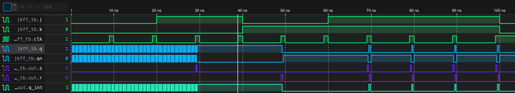

There are several strange things happen here:

#### What happen before around 30 ns?

The `Q` and `QN` oscillates at the same pace. Why? It’s because both `J` and `K` are zero. For a JK FF, this means to remember the last value. But the last value of `Q` and `QN` are both zero (we initialize them in the `JKFF.vhdl` file):

```
signal Q_int, QN_int : STD_LOGIC := '0'; -- Internal Q and QN for feedback
```

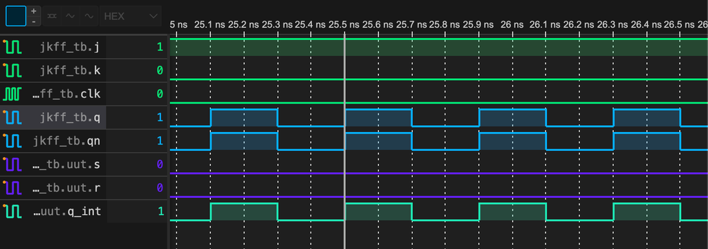

Locally zoomed in

OK, if instead we initialize the `Q` and `QN` a *valid* value, say `Q_int=0` and `QN_int=1` like this (in `JKFF.vhdl` file):

```
signal Q_int : STD_LOGIC := '0'; -- Internal Q for feedback
signal QN_int : STD_LOGIC := '1'; -- Internal QN for feedback
```

Since they are *valid*, hence stable, `Q` and `QN` will not oscillates as expected:

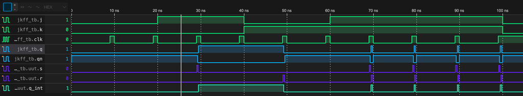

#### Why not toggle successfully?

At around $t = 70$ ns, both `J` and `K` are 1. This means at the leading edge of the clock signal `clk`, `Q` and `QN` should both flipped! But according to the waveform, they tried but failed, with a tiny pulse around that time.

I tried several `clk` pulse width and analysed the JK circuit in “slow-motion” carefully (Try this! Very surprising!). Finally I figured it out:

It’s because JK FF don’t want the `clk` signal be high for too long. This is because if the `clk` line hold high for a sufficient long period, the signal at `Q` and `QN` will “backpropagate” (Haha just borrow the term) to the inputs, continue to control whether or not the `J` and `K` signal should come in. If we increase the so-called “duty-ratio” of the `clk` signal, we will see these:

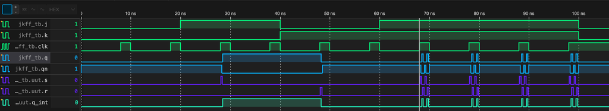

Duty ratio = 0.20

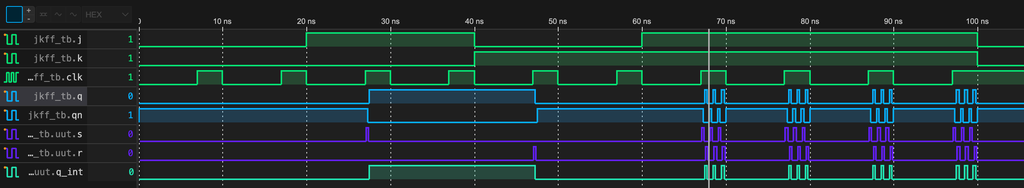

Duty ratio = 0.30

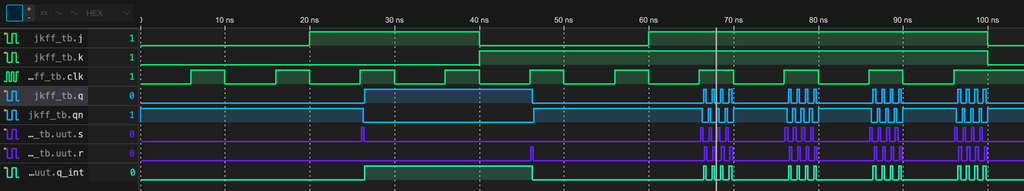

Duty ratio = 0.40

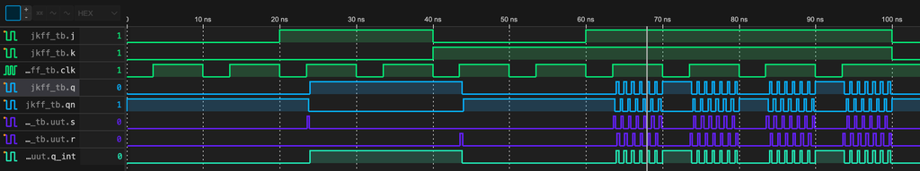

Duty ratio = 0.65

Some value of duty ratio (e.g. 0.65) happen to toggle the `Q` successfully, while others do not.

You can think of what value could the duty ratio be? (Given the clock cycle and the propagation delay of all gates) This is a very intereting yet tedious problem to consider. But as long as you understand why `Q` oscillates, you understand this.

Therefore people say that there are no “JK *latches*”.

## Conclusion

The VHDL realization of a JK FF can be achieved by introducing propagation delay to the gates.